# Negronis all round: simulation recovery of a discrete model 🍹

David Hodgson

2026-01-14

This vignette demonstrates how to recover a discrete latent variable model using simulated data on daily weather conditions and associated Negroni sales. The weather per day is a latent variable ($W$) that can take one of three states:

- Sunny ☀️,
- Cloudy ☁️
- Rainy 💧

and each state has its own distribution of Negroni sales 🍹. We’ll show how to infer the weather state for each day based on observed Negroni sales using a probabilistic modeling framework.

## 1. Relevant packages

```r
devtools::load_all()
#library(ptmc)
library(dplyr)
library(tidyr)
library(coda)


# Using more than one core might fail on windows,
if (.Platform$OS.type == "windows") {
  mc.cores <- 1
} else {
  mc.cores <- 2 # use as many as available, preferably 4.
}
```

## 2. Simulated data

We simulate the dataset as follows:

Each day of a month has an unobserved (“latent”) weather state ($W_i ${🌧️, ☁️, ☀️ }). We assume each weather is equally likely to happen on each day. For each weather condition, we have a different distribution of Negroni sales each day $Y_i$ which we assume follows:

- Sunny ☀️: $Y_i \sim \text{Poisson}(\lambda = 20)$
- Cloudy ☁️: $Y_i \sim \text{Poisson}(\lambda = 10)$
- Rainy 💧: $Y_i \sim \text{Poisson}(\lambda = 4)$

Based on this,let’s simulate some data:

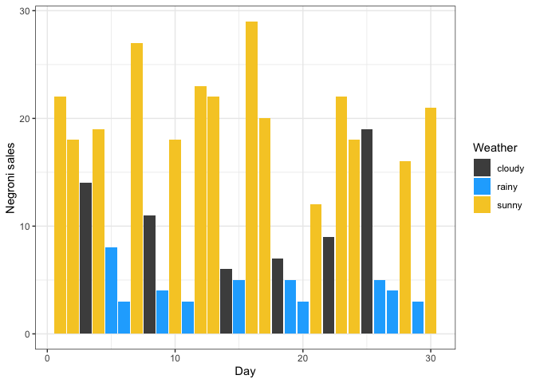

```r
set.seed(42)

# Parameters
n_days <- 30
weather_states <- c("sunny", "cloudy", "rainy")
lambda <- c(20, 10, 4)  # Poisson means for each weather state
prior_probs <- c(0.33, 0.33, 0.33)  # Prior probabilities for each weather state

# Generate latent weather states
latent_weather <- sample(weather_states, size = n_days, replace = TRUE, prob = prior_probs)

# Generate observed Negroni sales
sales <- sapply(latent_weather, function(w) {
  rpois(1, lambda[which(weather_states == w)])
})

# Combine into a data frame
data <- data.frame(day = 1:n_days, sales = sales, weather = latent_weather)

library(ggplot2)
# plot!
data %>%
  ggplot() +
    geom_col(aes(x = day, y = sales, fill = weather)) +
    scale_fill_manual(values = c("sunny" = "#f6cb2e", "cloudy" = "gray30", "rainy" = "#1eaefe")) +
    labs(x = "Day", y = "Negroni sales", fill = "Weather") + theme_bw()
```

## 3. Simulation recovery

### 3.1 Description of the model

In our Bayesian model we assume that Observed Negroi Sales ($Y_i$) are Poisson distributed with a rate parameter $\lambda_w$ that depends on the latent weather state $W_i$. That is the likelihood $P(Y_i | W_i = w)$ is Poisson with rate $\lambda_w$ for each weather state $w$. We assume the priors on the rate parameters $\lambda_w ~ \text{Unif}(0, 100)$. Finally, the prior distribution posterior distribution $P(W_i | Y_i)$ is given as the product of the likelihood and prior for each weather state $w$.

### 3.2 Steps to Recover $W_i$:

To recover the latent weather states, we use a Bayesian model with the following components:

1. **Define the Likelihood Function**: Implement the Poisson likelihood for $Y_i$ given $W_i = w$ for each weather state $w$.
2. **Calculate the posterior probabilities**: Use the likelihood and prior to compute the posterior probabilities for each $W_i$ using Bayes’ Rule.
3. **Infer the model probable state per day**: Assign each day to the weather state w with the highest posterior probability.
4. **Repeat for all days**: Perform the above inference for all days in the dataset to recover the sequence of latent weather states.

```r
data_t <- list(
  N = nrow(data),
  y = data$sale
)

# Add all of these entries into a model list

model <- list(

# 1. Parameter Bounds (lowerParSupport_fitted and upperParSupport_fitted)
# These define the lower and upper bounds for the three model parameters: w_r, w_c, and w_s.
# w_r, w_c, and w_s are restricted to lie between 0 and 100.
# This ensures that the values for each parameter remain within a reasonable range during model fitting or sampling.

  lowerParSupport_fitted = c(0, 0, 0),
  upperParSupport_fitted = c(100, 100, 100),

# 2. Parameter Names (namesOfParameters)
# namesOfParameters is a vector containing the names of the three parameters that the model will estimate:
#w_r: the rate associated with the first category (discrete value 1),
#w_c: the rate associated with the second category (discrete value 2),
#w_s: the rate associated with the third category (discrete value 3).
  namesOfParameters = c("w_r", "w_c", "w_s"),

## 3. Discrete Length (discrete_length)
# This is the length of the discrete sequence (i.e., the number of data points N). The model assumes that discrete has a length of 30, meaning there are 30 discrete latent variables to be inferred from the data, corresponding to 30 days.
  discrete_length = 30,

# 4. Sampling from Prior Distributions (samplePriorDistributions)
## The function samplePriorDistributions generates prior samples for the parameters w_r, w_c, and w_s.
## It samples each parameter independently from a uniform distribution between 0 and 100.

  samplePriorDistributions = function(datalist) {
    runif(3, 0, 100)
  },

# 5. Evaluating the Log-Prior (evaluateLogPrior)
# The function evaluateLogPrior calculates the log-prior of the model based on the parameters params (a vector containing w_r, w_c, and w_s).
  evaluateLogPrior = function(params, discrete, datalist) {

    lpr <- dunif( params, 0, 100, TRUE) %>% sum
    if (!(params[1] < params[2] & params[2] < params[3])) {
      lpr <- log(0)
    }
    lpr
  },

# 6. Initialising the Discrete Latent Variables (initialiseDiscrete)
# initialiseDiscrete initializes the discrete latent variables for each data point.
# The function samples N values (where N = 30 in this case) from the set {1, 2, 3}, assigning each data point to one of the three possible categories. This is done randomly with replacement.
  initialiseDiscrete = function(datalist) {
      require(purrr)

      N <- datalist$N

      discrete <- sample(1:3, N, replace = TRUE)
      discrete
    },

#7. Discrete Sampling (discreteSampling)
# discreteSampling is a function that updates the latent discrete variable using a random walk approach. It applies a random operation (based on the value of u) to the current state of the discrete vector:
#With probability 1/3, it randomly resamples one element of the discrete vector and assigns it to a new value from the set {1, 2, 3}.
#With probability 1/3, it swaps the values of two randomly selected elements in the discrete vector.
#With the remaining probability, no change is made to the discrete vector.
    discreteSampling = function(discrete, datalist) {

        u <- runif(1)
        N <- datalist$N
        # resample
        if (u < 0.33) {
          j <- sample(1:N, 1)
          discrete[j] <- sample(1:3, 1)
          # swap
        } else if(u < 0.66) {
          j_idx <- sample(1:N, 2)
          j_idx_1 <- discrete[j_idx[1]]
          discrete[j_idx[1]]  <- discrete[j_idx[2]]
          discrete[j_idx[2]] <- j_idx_1
        } else {
          # nothing happens!
        }
        return(discrete)
    },

# 8. Evaluating the Log-Likelihood (evaluateLogLikelihood)
# The function evaluateLogLikelihood calculates the log-likelihood for a set of parameter values params, given the observed data and the current state of the discrete latent variables.
# w_r, w_c, and w_s are the three model parameters (rates).
# The function iterates over each data point (from 1 to N, where N = 30), checking which category (discrete[i]) the data point belongs to.
#For each category (1, 2, or 3), it calculates the log-likelihood of the observed data point datalist$y[i] under the corresponding Poisson distribution with the rate parameter (w_r, w_c, or w_s).
#The log-likelihood is accumulated and returned as the total log-likelihood for the model.
  evaluateLogLikelihood = function(params, discrete, covariance, datalist) {
    w_r <- params[1]
    w_c <- params[2]
    w_s <- params[3]

    N <- datalist$N
    ll <- 0;
    for (i in 1:N) {
      if (discrete[i] == 1) {
         ll <- ll + dpois(datalist$y[i], w_r, log = TRUE)
      } else if (discrete[i] == 2) {
         ll <- ll + dpois(datalist$y[i], w_c, log = TRUE)
      } else {
         ll <- ll + dpois(datalist$y[i], w_s, log = TRUE)
      }

    }
    ll
  }
)
```

### 3.3. Settings and run model

Select the run time, chains, number of cores, burnin and thinning for the model.

```r
# Settings used for the ptmc model
settings <-  list(
  numberChainRuns = 2,
  numberCores = mc.cores,
  numberTempChains = 10,
  iterations = 100000,
  burninPosterior = 50000,
  thin = 100
)

post <- ptmc_discrete_func(model=model, data=data_t, settings=settings)
```